# ORIE5550 - Homework 2

Luis Alonso Cendra Villalobos (lc2234)

2024-02-09

# Problem 2.

Consider the time series deaths in the R package itsmr with the monthly accidental death numbers in the US, 1973-1978. Do the following for this time series:

## 2.a.

Use the R function decompose to obtain trend and seasonal components of the time series and plot the results; Produce a time plot depicting the time series and the sum of the trend and seasonal components; Produce a time plot and a correlogram of the residuals obtained after removing the trend and seasonal components from the series; Include the R code;

```r
#install.packages("itsmr")

library(itsmr)
deaths
```

```
##  [1]  9007  8106  8928  9137 10017 10826 11317 10744  9713  9938  9161  8927
## [13]  7750  6981  8038  8422  8714  9512 10120  9823  8743  9129  8710  8680
## [25]  8162  7306  8124  7870  9387  9556 10093  9620  8285  8433  8160  8034
## [37]  7717  7461  7776  7925  8634  8945 10078  9179  8037  8488  7874  8647
## [49]  7792  6957  7726  8106  8890  9299 10625  9302  8314  8850  8265  8796
## [61]  7836  6892  7791  8129  9115  9434 10484  9827  9110  9070  8633  9240
```

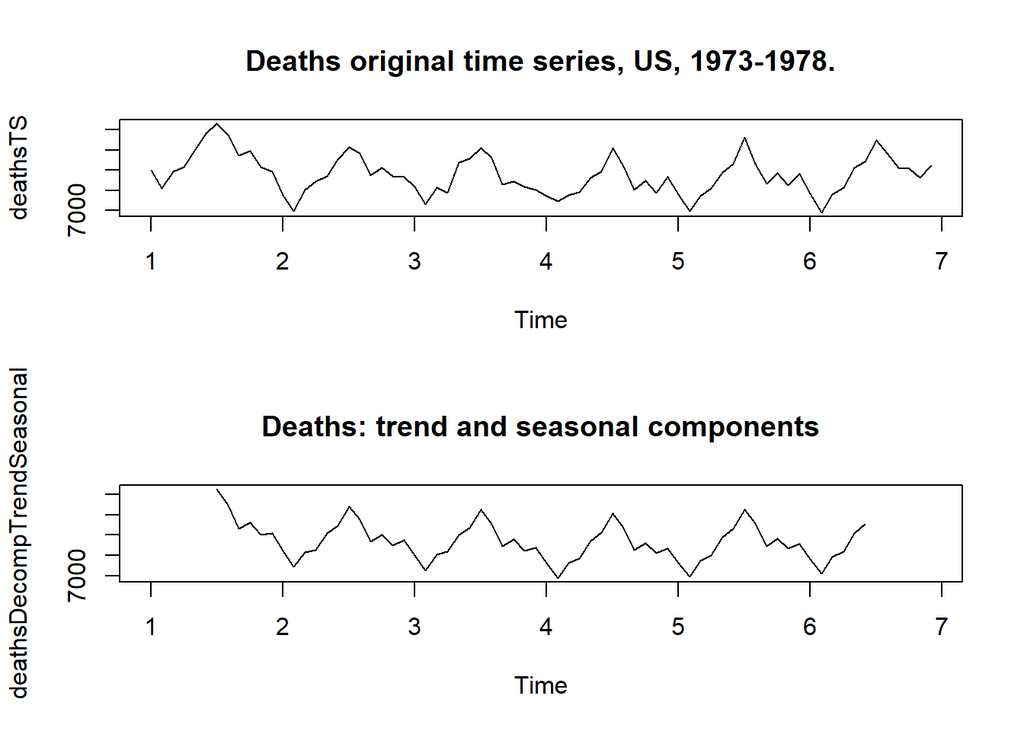

```r
deathsTS = ts(deaths, frequency=12)

deathsDecomp <- decompose(deathsTS, "additive")

deathsDecompTrendSeasonal <- deathsDecomp$trend + deathsDecomp$seasonal

par(mfrow=c(2,1))
plot.ts(deathsTS,  main = "Deaths original time series, US, 1973-1978.")
plot.ts(deathsDecompTrendSeasonal,  main = "Deaths: trend and seasonal components")
```

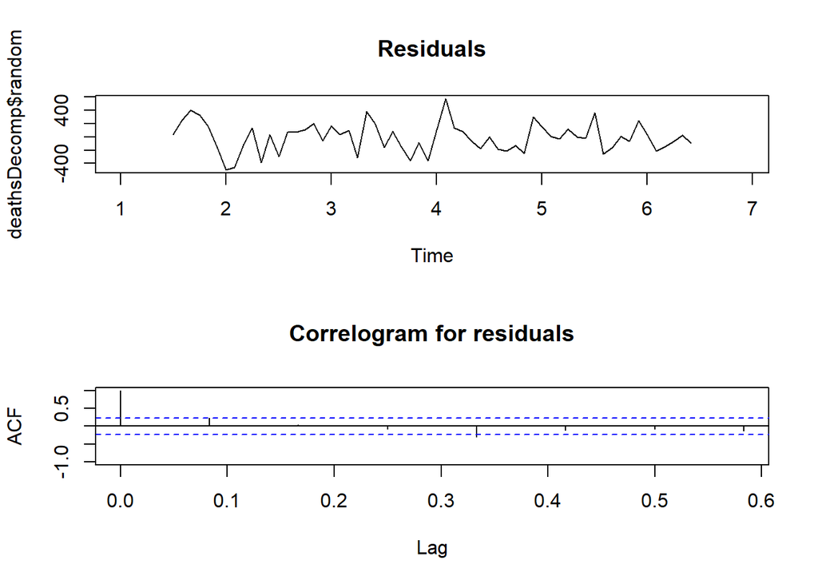

```r
par(mfrow=c(2,1))
plot.ts(deathsDecomp$random,  main = "Residuals")
acf(deathsDecomp$random, lag.max = 7,
    ylim = c(-1,1), main = "Correlogram for residuals",
    na.action = na.pass)
```

## 2.b.

Fit through least squares R function lm the quadratic trend and seasonal component (see HW paper for the equation) to the series and produce the fit results; Produce a time plot depicting the time series and the sum of the fitted trend and seasonal components; Produce a time plot and a correlogram of the residuals obtained after removing the trend and seasonal components from the series; Include the R code.

```r
tt <- seq(1,72)
y <- deathsDecompTrendSeasonal

#fit regression model
results <- lm( y ~ poly(tt, 2) +
                 cos(2*tt*pi/12) + sin(2*tt*pi/12) +
                 cos(2*tt*pi/6) + sin(2*tt*pi/6) +
                 cos(2*tt*pi/4) + sin(2*tt*pi/4), data = deathsDecompTrendSeasonal)
# poly trend and sine-cos is seasonal variance, 12 yerly, 6 semester, 4 quarter

#view model summary
summary(results)
```

```
##
## Call:
## lm(formula = y ~ poly(tt, 2) + cos(2 * tt * pi/12) + sin(2 *
##     tt * pi/12) + cos(2 * tt * pi/6) + sin(2 * tt * pi/6) + cos(2 *
##     tt * pi/4) + sin(2 * tt * pi/4), data = deathsDecompTrendSeasonal)
##
## Residuals:
##     Min      1Q  Median      3Q     Max
## -401.08 -209.45   21.03  183.86  461.17
##
## Coefficients:
##                     Estimate Std. Error t value Pr(>|t|)
## (Intercept)          8781.49      37.13 236.495  < 2e-16 ***
## poly(tt, 2)1        -1950.14     345.25  -5.648 7.25e-07 ***
## poly(tt, 2)2         2476.48     407.40   6.079 1.54e-07 ***
## cos(2 * tt * pi/12)  -716.12      47.18 -15.179  < 2e-16 ***
## sin(2 * tt * pi/12)  -754.52      47.67 -15.827  < 2e-16 ***
## cos(2 * tt * pi/6)    398.97      47.15   8.462 2.77e-11 ***
## sin(2 * tt * pi/6)     82.16      47.23   1.740  0.08795 .
## cos(2 * tt * pi/4)    157.13      47.15   3.333  0.00161 **
## sin(2 * tt * pi/4)   -213.82      47.15  -4.535 3.52e-05 ***
## ---
## Signif. codes:  0 '***' 0.001 '**' 0.01 '*' 0.05 '.' 0.1 ' ' 1
##
## Residual standard error: 258 on 51 degrees of freedom
##   (12 observations deleted due to missingness)
## Multiple R-squared:  0.9317, Adjusted R-squared:  0.921
## F-statistic:    87 on 8 and 51 DF,  p-value: < 2.2e-16
```

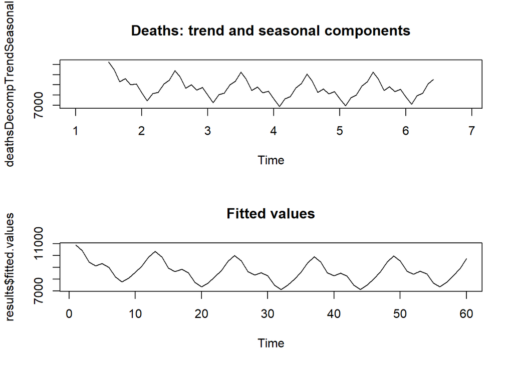

```r
par(mfrow=c(2,1))
plot.ts(deathsDecompTrendSeasonal,  main = "Deaths: trend and seasonal components")
plot.ts(results$fitted.values,  main = "Fitted values")
```

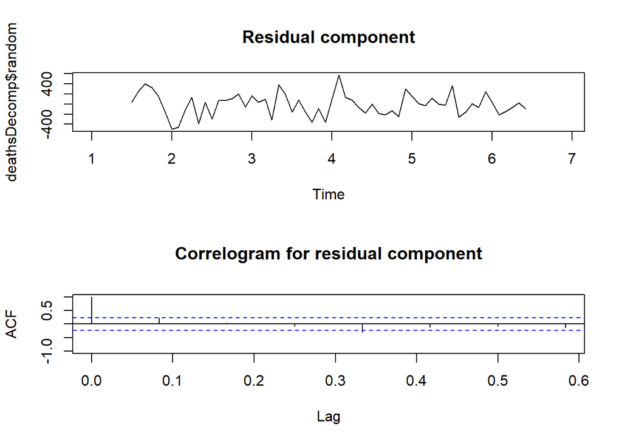

```r
par(mfrow=c(2,1))
plot.ts(deathsDecomp$random,  main = "Residual component")
acf(deathsDecomp$random, lag.max = 7,
    ylim = c(-1,1), main = "Correlogram for residual component",
    na.action = na.pass)
```

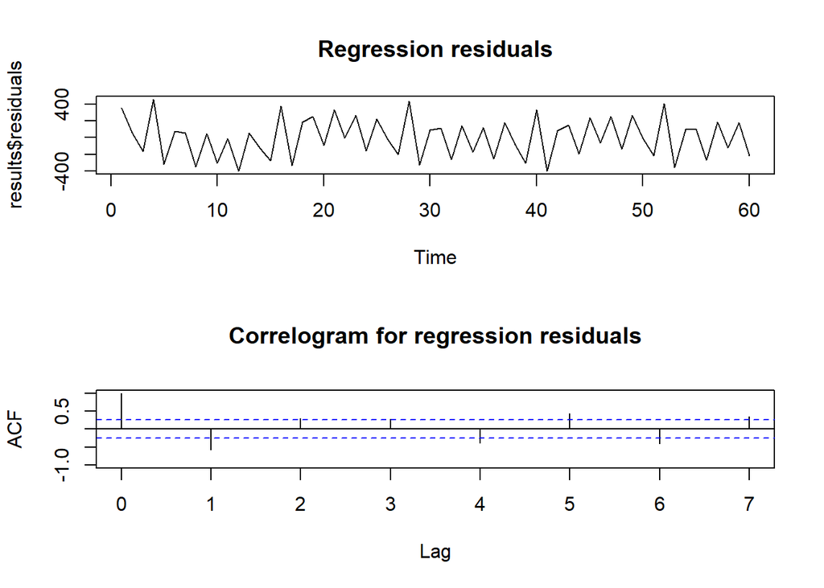

```r
par(mfrow=c(2,1))
plot.ts(results$residuals,  main = "Regression residuals")
acf(results$residuals, lag.max = 7,
    ylim = c(-1,1), main = "Correlogram for regression residuals",
    na.action = na.pass)
```

# Problem 4.

Thoughsample ACFwaspresented in class as a tool for stationary models, note that it could also be computed for any time series. In fact, if time series have trends or/and seasonal components, this could also be seen from their correlograms.

## 4.a.

Read the time series data prices from the R package fpp3 and produce a time plot of the series prices$wheat; As you will see, the series clearly has a decreasing trend. Now, produce and include a correlogram of this series up to lag 30; Explain the pattern that you see; Supplement your explanation by drawing a few scatter plots of xt versus xt−h, the correlation between which yields the sample ACF at lag h.

```r
#install.packages("fpp3")
library("fpp3")
```

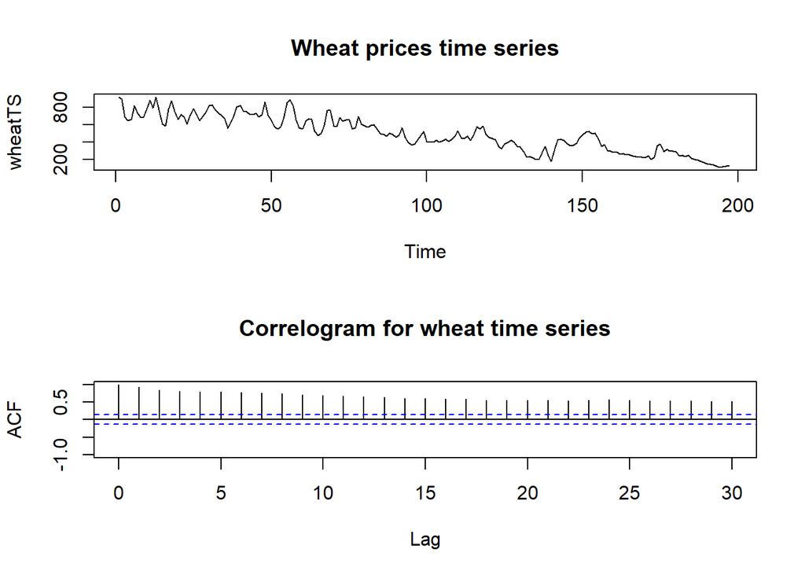

```r
wheatTS = ts(prices$wheat, frequency=1)


tt <- length(wheatTS)

par(mfrow=c(2,1))
plot.ts(wheatTS, main = "Wheat prices time series")
acf(wheatTS, lag.max = 30,
    ylim = c(-1,1), main = "Correlogram for wheat time series",
    na.action = na.pass)
```

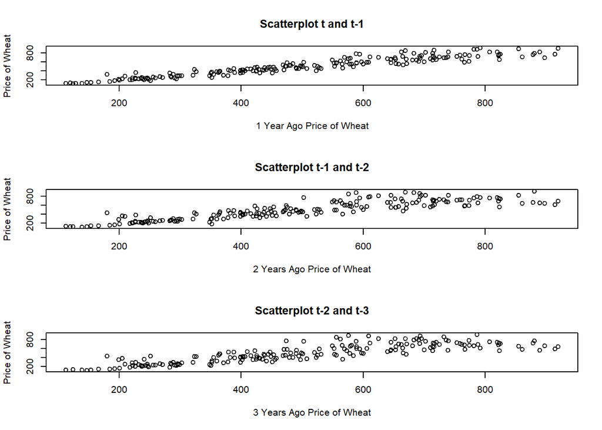

```r
par(mfrow=c(3,1))
plot(y=wheatTS[2:tt], x=wheatTS[1:(tt-1)], ylab = 'Price of Wheat', xlab = '1 Year Ago Price of Wheat', main = "Scatterplot t and t-1")
plot(y=wheatTS[3:tt], x=wheatTS[1:(tt-2)], ylab = 'Price of Wheat', xlab = '2 Years Ago Price of Wheat', main = "Scatterplot t-1 and t-2")
plot(y=wheatTS[4:tt], x=wheatTS[1:(tt-3)], ylab = 'Price of Wheat', xlab = '3 Years Ago Price of Wheat', main = "Scatterplot t-2 and t-3")
```

### Explanation:

From the Autocorrelation Functions (ACF) we can observe that lags, even up to 30, are significant and decay very slowly. This indicates the wheat prices today are auto correlated with prices up to 30 years prior. This could be because the series is not stationary (although we cannot state it from the ACFs alone), which is exhibited by the decreasing trend in the plot.Some reasons may be an overall increase in wheat producers globally (Argentina, China, etc.), the entry of wheat substitutes to the market, changes in global consumer preferences (as living standards rise, wheat consumption may not), etc. Additionally, from the scatter plots we can see that prices are likely correlated across years.

## 4.b.

Read the time series data bank calls from the R package fpp3. The data is a five-minute call volume handled on weekdays between 7:00am and 9:05pm, beginning 3 March 2003 for 164 days; Aggregate the volume data into 2-hour blocks, 7am-9am, 9am-11am, …, with the every last block 7pm-9:05pm of each day being 5 minutes longer; Produce the time plot of the aggregated time series for the first 50 days; As you will see, the series clearly exhibits seasonal variations. Now, produce and include a correlogram of this series up to lag 40; Explain the pattern that you see; Supplement your explanation by drawing a few scatter plots of xt versus xt−h as the problem above.

```r
df <- as.data.frame(bank_calls) # transform to dataframe

#remove UTC tag
date_as_posix <- strptime(df$DateTime, format="%Y-%m-%d %H:%M:%S", tz="UTC")
invisible(strftime(date_as_posix, format="%Y-%m-%d %H:%M", tz="UTC"))

# matrix with 164 rows (days) and 7 cols (intervals)
aggregate <- matrix(0, nrow = 164, ncol = 7)

# start on day 1
day_count = 1

#start looping through the matrix starting in day 1 until day 164
for (i in seq_along(df$DateTime)) {

  # if day changes, sum one to the index pointer
  if (date(df$DateTime[i]) != date(df$DateTime[i-1]) && i > 1) {
    day_count = day_count + 1
  }

  # Check under which interval the timestamp falls into and sum the calls
  if (hour(df$DateTime[i]) >= 7 && hour(df$DateTime[i]) < 9 ) {
    aggregate[day_count,1] = aggregate[day_count,1] + df$Calls[i]
  }
  if (hour(df$DateTime[i]) >= 9 && hour(df$DateTime[i]) < 11 ) {
    aggregate[day_count,2] = aggregate[day_count,2] + df$Calls[i]
  }
  if (hour(df$DateTime[i]) >= 11 && hour(df$DateTime[i]) < 13 ) {
    aggregate[day_count,3] = aggregate[day_count,3] + df$Calls[i]
  }
  if (hour(df$DateTime[i]) >= 13 && hour(df$DateTime[i]) < 15 ) {
    aggregate[day_count,4] = aggregate[day_count,4] + df$Calls[i]
  }
  if (hour(df$DateTime[i]) >= 15 && hour(df$DateTime[i]) < 17 ) {
    aggregate[day_count,5] = aggregate[day_count,5] + df$Calls[i]
  }
  if (hour(df$DateTime[i]) >= 17 && hour(df$DateTime[i]) < 19 ) {
    aggregate[day_count,6] = aggregate[day_count,6] + df$Calls[i]
  }
  if (hour(df$DateTime[i]) >= 19 && hour(df$DateTime[i]) <= 21 ) {
    aggregate[day_count,7] = aggregate[day_count,7] + df$Calls[i]
  }
}

print("First 50 days of each interval are plotted below.")
```

```
## [1] "First 50 days of each interval are plotted below."
```

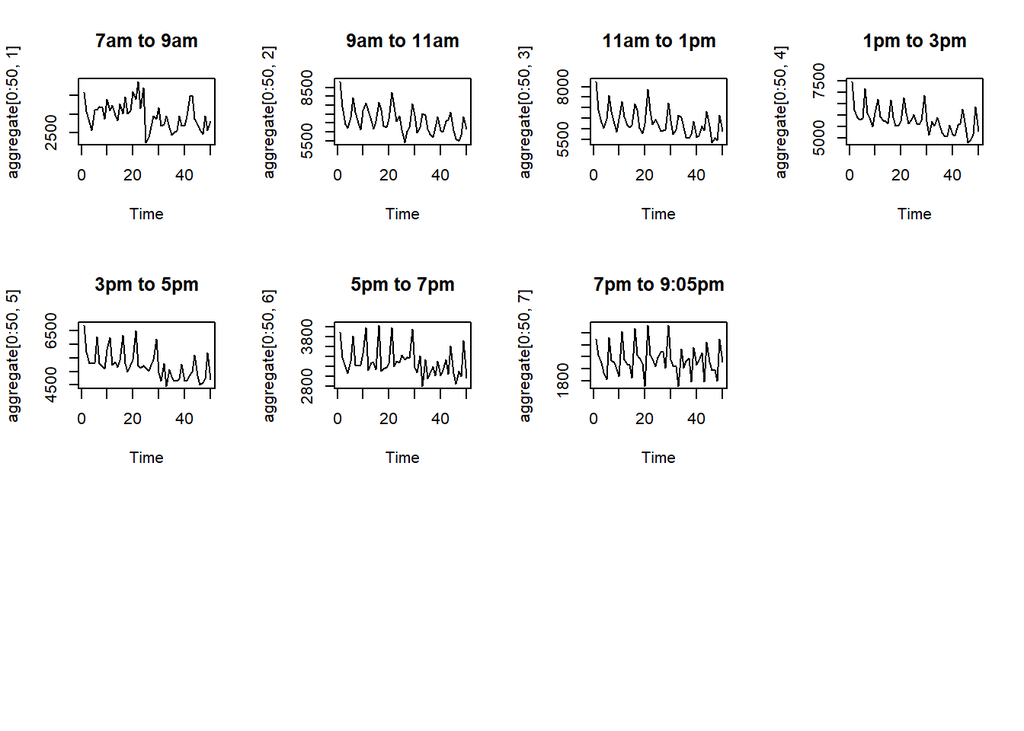

```r
par(mfrow=c(3,4))
plot.ts(aggregate[0:50,1], main = "7am to 9am")
plot.ts(aggregate[0:50,2], main = "9am to 11am")
plot.ts(aggregate[0:50,3], main = "11am to 1pm")
plot.ts(aggregate[0:50,4], main = "1pm to 3pm")
plot.ts(aggregate[0:50,5], main = "3pm to 5pm")
plot.ts(aggregate[0:50,6], main = "5pm to 7pm")
plot.ts(aggregate[0:50,7], main = "7pm to 9:05pm")


par(mfrow=c(3,4))
```

```r
print("Correlograms up to lag 40 for each interval are plotted below.")
```

```
## [1] "Correlograms up to lag 40 for each interval are plotted below."
```

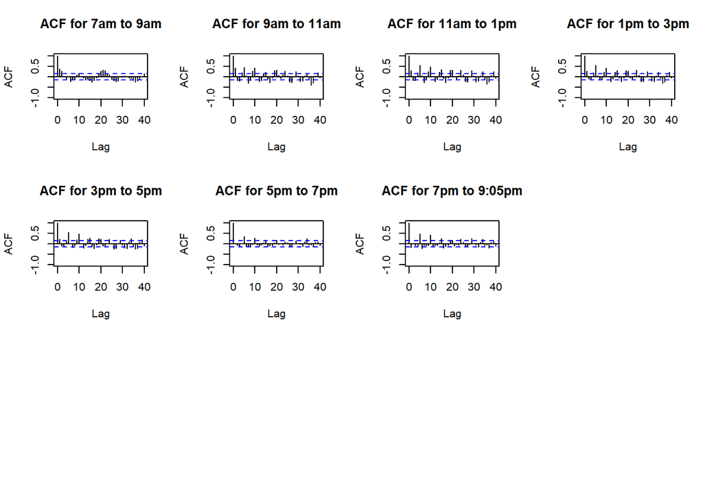

```r
acf(aggregate[,1], lag.max = 40,
    ylim = c(-1,1), main = "ACF for 7am to 9am",
    na.action = na.pass)
acf(aggregate[,2], lag.max = 40,
    ylim = c(-1,1), main = "ACF for 9am to 11am",
    na.action = na.pass)
acf(aggregate[,3], lag.max = 40,
    ylim = c(-1,1), main = "ACF for 11am to 1pm",
    na.action = na.pass)
acf(aggregate[,4], lag.max = 40,
    ylim = c(-1,1), main = "ACF for 1pm to 3pm",
    na.action = na.pass)
acf(aggregate[,5], lag.max = 40,
    ylim = c(-1,1), main = "ACF for 3pm to 5pm",
    na.action = na.pass)
acf(aggregate[,6], lag.max = 40,
    ylim = c(-1,1), main = "ACF for 5pm to 7pm",
    na.action = na.pass)
acf(aggregate[,7], lag.max = 40,
    ylim = c(-1,1), main = "ACF for 7pm to 9:05pm",
    na.action = na.pass)
```

### Due to space constraints, I will only present the scatterplots for the 9am to 11am time interval

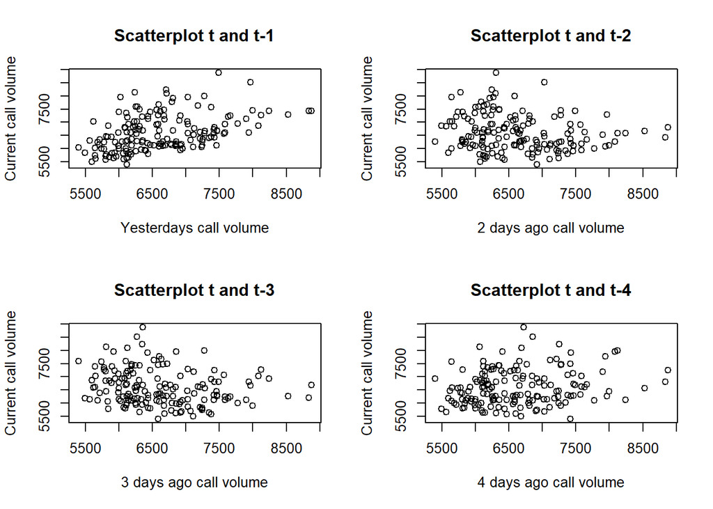

```r
tt <- length(aggregate[,2])

par(mfrow=c(2,2))
plot(y=aggregate[2:tt,2], x=aggregate[1:(tt-1),2], ylab = 'Current call volume',
     xlab = 'Yesterdays call volume', main = "Scatterplot t and t-1")
plot(y=aggregate[3:tt,2], x=aggregate[1:(tt-2),2], ylab = 'Current call volume',
     xlab = '2 days ago call volume', main = "Scatterplot t and t-2")
plot(y=aggregate[4:tt,2], x=aggregate[1:(tt-3),2], ylab = 'Current call volume',
     xlab = '3 days ago call volume', main = "Scatterplot t and t-3")
plot(y=aggregate[5:tt,2], x=aggregate[1:(tt-4),2], ylab = 'Current call volume',
     xlab = '4 days ago call volume', main = "Scatterplot t and t-4")
```

### Explanation:

From the first 50 days plot, we can see that there are seasonal variations for this series. Interestingly, all plots start at a peak, and the first date of the series is March 3rd, 2003, which is a Monday; further, the number of peaks in the graphs is close to the number of Mondays in the time interval (50/5 ~ 10). We could make a hypothesis that bank calls are higher during Mondays. Possible reasons are: there is no customer service during the weekends (which is exhibited in the database), therefore, cases start queuing until they are resolved on Monday; or maybe, people wait until Monday to “get up to date” with financial responsibilities; or, most problems related with bank clients occur during the weekends (e.g., denied or lost cards), etc.

From the Autocorrelation Functions (ACF) we can observe that for most 2-hour blocks, the lags 1 and multiples of 5 (5,10, etc.) appear to be significant further motivating the Monday’s hypothesis. The rest of lags do not seem to be significant and decay very sharply. This indicates the bank calls are not auto correlated with previous days calls, which could be an indicator of successful customer service (a client whose problem has been solved wont call back) or rather a reflection of the characteristics of the call (for instance, these could be calls asking for one-off information or help, like “I cant access my online banking.” or “I lost my card, can you replace it?”).

## 4.c.

Read the time series data canadian gas from the R package fpp3, giving monthly Canadian gas production, billions of cubic metres, January 1960- February 2005; Produce its time plot; As you will see, the series clearly has a trend and exhibits seasonal variations. Now, produce and include a correlogram of this series; Explain the pattern that you see; Supplement your explanation by drawing a few scatter plots of xt versus xt−h as the problems above.

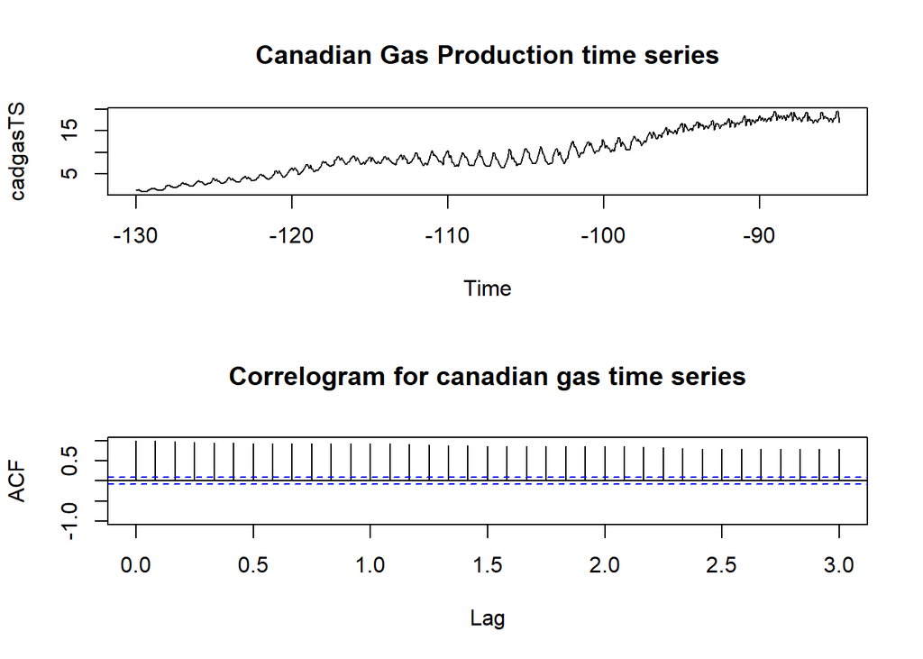

```r
cadgasTS = ts(canadian_gas$Volume, canadian_gas$Month, frequency=12)


tt <- length(cadgasTS)

par(mfrow=c(2,1))
plot.ts(cadgasTS, main = "Canadian Gas Production time series")
acf(cadgasTS, lag.max = 36,
    ylim = c(-1,1), main = "Correlogram for canadian gas time series",
    na.action = na.pass)
```

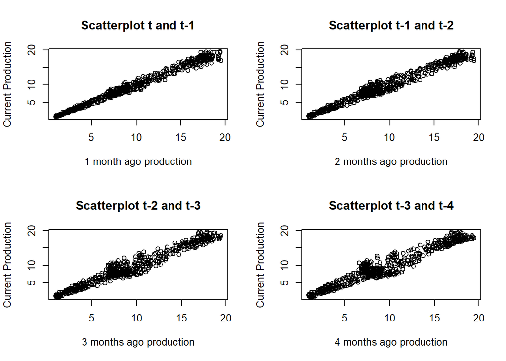

```r
par(mfrow=c(2,2))
plot(y=cadgasTS[2:tt], x=cadgasTS[1:(tt-1)], ylab = 'Current Production', xlab = '1 month ago production', main = "Scatterplot t and t-1")
plot(y=cadgasTS[3:tt], x=cadgasTS[1:(tt-2)], ylab = 'Current Production', xlab = '2 months ago production', main = "Scatterplot t-1 and t-2")
plot(y=cadgasTS[4:tt], x=cadgasTS[1:(tt-3)], ylab = 'Current Production', xlab = '3 months ago production', main = "Scatterplot t-2 and t-3")
plot(y=cadgasTS[5:tt], x=cadgasTS[1:(tt-4)], ylab = 'Current Production', xlab = '4 months ago production', main = "Scatterplot t-3 and t-4")
```

### Explanation:

From the Autocorrelation Functions (ACF) we can observe that lags, even up to 36, are significant and decay very slowly. This indicates the Canadian gas monthly production today are auto correlated with prices up to 36 months prior. This could be because the series is not stationary (although we cannot state it from the ACFs alone), which is exhibited by the seasonality variations and trend in the plot. Additionally, from the scatter plots we can see that current production is correlated with previous months production. Some reasons may that shocks that affect gas production are persistent through time, gas production could be regulated and quotas implemented, gas is consumed the highest during winter months, among others.